# 8 The graph of a function

This section will use the following packages:

```julia
using CalculusWithJulia
using Plots
plotly();
```

A scalar, univariate function, such as $f(x) = 1 - x^2/2$, can be thought of in many different ways. For example:

- It can be represented through a rule of what it does to $x$, as above. This is useful for computing numeric values.
- it can be interpreted verbally, as in *square* $x$, take half, then *subtract* from one. This can give clarity to what the function does.
- It can be thought of in terms of its properties: a polynomial, continuous, upside down $U$-shaped, an approximation for $\cos(x)$ near $0$, $\dots$
- it can be visualized graphically. This is useful for seeing the qualitative behavior of a function.

The last one is the focus of this section.

The graph of a univariate function is just a set of points in the Cartesian plane. These points come from the relation $(x,f(x))$ that defines the function. Operationally, a sketch of the graph will consider a handful of such pairs and then the rest of the points will be imputed.

For example, a typical approach to plot $f(x) = 1 - x^2/2$ would be to choose some values for $x$ and find the corresponding values of $y$. This might be organized in a “T”-table:

```
 x | y
--------
-2 |  -1
-1 |  1/2
 0 |   1
 1 |  1/2
 2 |  -1
 3 | -7/2
```

These pairs would be plotted in a Cartesian plane and then connected with curved lines. A good sketch is aided by knowing ahead of time that this function describes a parabola which is curving downwards.

We note that this sketch would not include *all* the pairs $(x,f(x))$, as their extent is infinite, rather a well chosen collection of points over some finite domain.

## 8.1 Graphing a function with Julia

`Julia` has several different options for rendering graphs, all in external packages. We will focus in these notes on the `Plots` package, which provides a common interface to several different plotting backends. (Click through for instructions for plotting with the Makie package or the PlotlyLight package.) At the top of this section the accompanying `CalculusWithJulia` package and the `Plots` package were loaded with the `using` command, like this:

```julia
using CalculusWithJulia
using Plots
```

**NoteNote**

`Plots` is a frontend for one of several backends. `Plots` comes with a backend for web-based graphics (call `plotly()` to specify that); a backend for static graphs (call `gr()` for that). If the `PyPlot` package is installed, calling `pyplot()` will set that as a backend. For terminal usage, if the `UnicodePlots` package is installed, calling `unicodeplots()` will enable that usage. There are still other backends.

Some backends require installation, such as `PyPlot` and `PlotlyJS`. We use `plotly` in these notes, for the most part, which is not the default, so requires an additional command to set the backend:[^1]

```julia
plotly()
```

```
Plots.PlotlyBackend()
```

(Certain graphics are produced with the `gr()` backend.)

With `Plots` loaded and a backend chosen, it is straightforward to graph a function.

For example, to graph $f(x) = 1 - x^2/2$ over the interval $[-3,3]$ we have:

```julia
f(x) = 1 - x^2/2
plot(f, -3, 3)
```

Figure 8.1: Plot of $f(x) = 1 - x^2/2$ over $[-3,3]$

The `plot` command does the hard work behind the scenes. It needs $2$ pieces of information declared:

- **What** to plot. With this invocation, this detail is expressed by passing a function object to `plot`
- **Where** to plot; the `xmin` and `xmax` values. As with a sketch, it is impossible in this case to render a graph with all possible $x$ values in the domain of $f$, so we need to pick some viewing window. In the example this has $x$ limits of $[-3,3]$; expressed by passing the two endpoints as the second and third arguments.

Plotting a function is then this simple: `plot(f, xmin, xmax)`.

> *A basic template:* Many operations we meet will take the form `action(function, args...)`, as the call to `plot` does. The template shifts the focus to the action to be performed. This is a [declarative](http://en.wikipedia.org/wiki/Declarative_programming) style, where the details to execute the action are only exposed as needed.

Let’s see some other graphs.

The `sin` function over one period is plotted through:

```julia
plot(sin, 0, 2pi)
```

Figure 8.2: Plot of $f(x) = \sin(x)$ over $[0, 2\pi]$

We can make a graph of $f(x) = (1+x^2)^{-1}$ over $[-3,3]$ with:

```julia
f(x) = 1 / (1 + x^2)
plot(f, -3, 3)
```

Figure 8.3: Plot of $f(x) = 1 / (1 + x^2)$ over $[-3, 3]$

A graph of $f(x) = e^{-x^2/2}$ over $[-2,2]$ is produced with:

```julia
f(x) = exp(-x^2/2)
plot(f, -2, 2)
```

Figure 8.4: Plot of $f(x) = e^{-x^2/2}$ over $[-2, 2]$

We could skip the first step of defining a function by using an *anonymous function*. For example, to plot $f(x) = \cos(x) - x$ over $[0, \pi/2]$ we could do:

```julia
plot(x -> cos(x) - x, 0, pi/2)
```

Figure 8.5: Plot of $f(x) = \cos(x)-x$ over $[0, \pi/2]$ using an anonymous function

Anonymous functions are especially helpful when parameterized functions are involved:

```julia
mxplusb(x; m=1, b=0) = m*x + b
plot(x -> mxplusb(x; m=-1, b=1), -1, 2)
```

Figure 8.6: Plot of $f(x) = -x + 1$ over $[-1,2]$ using an anonymous function

Had we parameterized using the `f(x,p)` style, the result would be similar:

```julia
function mxplusb(x, p)
    m, b = p.m, p.b
    m * x + b
end
plot(x -> mxplusb(x, (m=-1, b=1)), -1, 2)
```

Figure 8.7: Plot of $f(x) = -x + 1$ over $[-1,2]$ using an anonymous function and the “`f(x,p)`” style of passing parameters

**NoteNote**

The function object in the general pattern `action(function, args...)` is commonly specified in one of three ways: by a name, as with `f`; as an anonymous function; or as the return value of some other action through composition.

Anonymous functions are also created by `Julia's` `do` notation, which is useful when the first argument to function (like `plot`) accepts a function:

```julia
plot(0, pi/2) do x
    cos(x) - x
end
```

Figure 8.8: Plot of $f(x) = \cos(x) -x$ over $[0,\pi/2]$ illustrating use of `Julia`’s `do` notation

The `do` notation can be a bit confusing to read when unfamiliar, though its convenience makes it appealing.

**NoteNote**

Some types we will encounter, such as the one for symbolic values or the special polynomial one, have their own `plot` recipes that allow them to be plotted similarly as above, even though they are not functions.

**NoteViewing window**

The default style for `Plots.jl` is to use a frame style where the viewing window is emphasized. This is a rectangular region, $[x_0, x_1] \times [y_0, y_1]$, which is seen through the tick labeling, the bounding scales on the left and bottom, and emphasized through the grid.

This choice does *not* show the $x-y$ axes. As such, we might layer on the axes when these are of interest.

To emphasize concepts, we may stylize a function graph, rather than display the basic graphic. For example, in this graphic highlighting the amount the function goes up as it moves from $1$ to $x$:

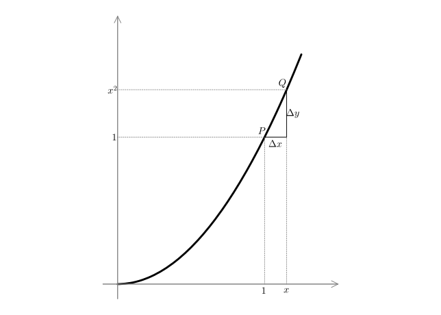

Making a graph with `Plots` is easy, but producing a graph that is informative can be a challenge, as the choice of a viewing window can make a big difference in what is seen. For example, trying to make a graph of $f(x) = \tan(x)$, as below, will result in a bit of a mess—the chosen viewing window crosses several places where the function blows up:

```julia
f(x) = tan(x)
plot(f, -10, 10)
```

Figure 8.9: Plot of $f(x) = \tan(x)$ over $[-10,10]$. The vertical asymptotes of the function result in a poor graphic.

Though this graph shows the asymptote structure and periodicity, it doesn’t give much insight into each period or even into the fact that the function is periodic.

## 8.2 The details of graph making

The actual details of making a graph of $f$ over $[a,b]$ are pretty simple and follow the steps in making a “T”-table:

- A set of $x$ values are created between $a$ and $b$.
- A corresponding set of $y$ values are created.
- The pairs $(x,y)$ are plotted as points and connected with straight lines.

If the first two lines create values `xs` and `ys` then the last is done by calling `plot(xs, ys)`.

The only real difference is that when drawing by hand, we might know to curve the lines connecting points based on an analysis of the function. As `Julia` doesn’t consider this, the points are connected with straight lines – like a dot-to-dot puzzle.

In general, the `x` values are often generated by the `range` or the `colon` operator and the `y` values produced by mapping or broadcasting a function over the generated `x` values.

However, the plotting directive `plot(f, xmin, xmax)`, in computing values for `x` to plot, calls an adaptive algorithm to use more points where needed, as judged by `PlotUtils.adapted_grid(f, (xmin, xmax))`. It computes both the `x` and `y` values. This algorithm is wrapped up into the `unzip(f, xmin, xmax)` function from `CalculusWithJulia`. The algorithm adds more points where the function is more “curvy” and uses fewer points where it is “straighter.” Here we see the linear function is identified as needing far fewer points than the oscillating function when plotted over the same range:

```julia
function pts_needed(f, xmin, xmax)
    xs, ys = unzip(f, xmin, xmax)
    length(xs)
end
pts_needed(x -> 10x, 0, 10), pts_needed(x -> sin(10x), 0, 10)
```

```
(31, 1611)
```

(In fact, the `31` is the minimum number of points used for any function; a linear function only needs two.)

For instances where a *specific* set of $x$ values is desired to be used, the `range` function or colon operator can be used to create the $x$ values and broadcasting used to create the $y$ values. For example, if we were to plot $f(x) = \sin(x)$ over $[0,2\pi]$ using $10$ points, we might do the three steps, passing the values to `plot` as follows:

```julia
xs = range(0, 2pi, 10)
ys = sin.(xs)
plot(xs, ys)
```

Figure 8.10: Plot of $f(x) = \sin(x)$ over $[0,2\pi]$ using the `f(xs, ys)` style

The `plot` function plots the points as pairs and then connects them in order using straight lines. Basically, it creates a dot-to-dot graph. The above graph looks primitive, as it doesn’t utilize enough points.

##### Example: Reflections

The graph of a function may be reflected through a line, as those seen with a mirror. For example, a reflection through the $y$ axis takes a point $(x,y)$ to the point $(-x, y)$. We can easily see this graphically, when we have sets of $x$ and $y$ values through a judiciously placed minus sign.

For example, to plot $\sin(x)$ over $(-\pi,\pi)$ we might specify `xs`, generate `ys` and then call `plot(xs, ys)`.

```julia
xs = range(-pi, pi, length=100)
ys = sin.(xs)
plot(xs, ys)
```

To reflect this graph through the $y$ axis, we only need to plot `-xs` and not `xs`.

```julia
plot(-xs, ys)
```

There are four very common reflections:

- reflection through the $y$-axis takes $(x,y)$ to $(-x, y)$.
- reflection through the $x$-axis takes $(x,y)$ to $(x, -y)$.
- reflection through the origin takes $(x,y)$ to $(-x, -y)$.
- reflection through the line $y=x$ takes $(x,y)$ to $(y,x)$.

Figure 8.12 shows the different graphs. For the $\sin(x)$ graph, we see that reflecting through the $x$ axis produces the same graph as reflecting through the $y$ axis. Doing both reflections (e.g., through the $x$ axis, then the $y$ axis) is the same as reflecting through the origin and for this function leaves the graph unchanged.

> An *even function* is one where reflection through the $y$ axis leaves the graph unchanged. That is, $f(-x) = f(x)$. An *odd function* is one where a reflection through the origin leaves the graph unchanged, or $f(-x) = -f(x)$.

Figure 8.12: Plot of the four common reflections for $f(x) = \sin(x)$ along with a line or point indicated what the reflection was through. This function is an odd function, so the graph is left unchanged by reflection through the origin (lower left).

The reflection of $f(x) = \sin(x)$ through the line $y=x$ leads to a graph of the equation $x = \sin(y)$. The result is not the graph of a function as the same $x$ can map to more than one $y$ value. (The new graph does not pass the “vertical line” test.) However, for the sine function we can get a function from this reflection if we choose a narrower viewing window:

```julia
xs = range(-pi/2, pi/2, length=100)
ys = sin.(xs)
plot(ys, xs)
```

Figure 8.13: Inverse plot of $f(x)=\sin(x)$ over $[-\pi/2, \pi/2]$ using `plot(ys, xs)`

The graph is that of the “inverse function” for $\sin(x), x \text{ in } [-\pi/2, \pi/2]$.

#### NaN values

At times it is not desirable to draw lines between each successive point. For example, if there is a discontinuity in the function or if there were a vertical asymptote.

For example,what happens at $0$ with $f(x) = 1/x$. The most straightforward plot is dominated by the vertical asymptote at $x=0$:

```julia
q(x) = 1/x
plot(q, -1, 1)
```

Figure 8.14: Plot of $f(x) = 1/x$ over $[-1,1]$ showing effect on graphic of vertical asymptote

We can attempt to improve this graph by adjusting the viewport. The *viewport* of a graph is the $x$-$y$ range of the viewing window. By default, the $y$-part of the viewport is determined by the range of the function over the specified interval, $[a,b]$. As just seen, this approach can produce poor graphs. The `ylims=(ymin, ymax)` argument can modify what part of the $y$ axis is shown. (Similarly `xlims=(xmin, xmax)` will modify the viewport in the $x$ direction.)

As we see, even with this adjustment, the spurious line connecting the points with $x$ values closest to $0$ is still drawn:

```julia
plot(q, -1, 1, ylims=(-10,10))
```

Figure 8.15: Plot of $f(x) = 1/x$ over $[-1,1]$ using `ylims` to reduce effect on graphic of vertical asymptote

The dot-to-dot algorithm, at some level, assumes the underlying function is *continuous*; here $q(x)=1/x$ is not.

There is a convention for most plotting programs that **if** the $y$ value for a point is `NaN` then no lines will connect to that point, `(x,NaN)`. `NaN` conveniently appears in many cases where a plot may have an issue, though not with $1/x$ as `1/0` is `Inf` and not `NaN`. (Unlike, say, `0/0` which is NaN.)

Here is one way to plot $q(x) = 1/x$ over $[-1,1]$ taking advantage of this convention:

```julia
xs = range(-1, 1, length=251)
ys = q.(xs)
ys[xs .== 0.0] .= NaN
plot(xs, ys)
```

Figure 8.16: Plot of $f(x) = 1/x$ after setting `y` values to `NaN` when `x` is zero

By using an odd number of points, we should have that $0.0$ is amongst the `xs`. The next to last line replaces the $y$ value that would be infinite with `NaN`.

The above is fussy. As a recommended alternative, we might modify the function so that if it is too large, the values are replaced by `NaN`. Here is one such function consuming a function and returning a modified function put to use to make this graph]:

```julia
rangeclamp(f, hi=20, lo=-hi; replacement=NaN) = x -> lo < f(x) < hi ? f(x) : replacement
plot(rangeclamp(x -> 1/x), -1, 1)
```

Figure 8.17: Plot of $f(x) = 1/x$ over $[-1, 1]$ after wrapping in `rangclamp` to replace large `y` values in (absolute value) with `NaN`.

(The `clamp` function is a base `Julia` function and has slightly different semantics. It clamps a number between `lo` and `hi`, returning `lo` or `hi` (not `NaN`) if `x`is outside that range. The `rangeclamp` function is part of the `CalculusWithJulia` package and need not be defined if that package is loaded.)

## 8.3 Layers

Graphing more than one function over the same viewing window is often desirable. Though this is easily done all at once in `Plots`, we instead focus on building the graph layer by layer.[^2]

For example, to see that a polynomial and the cosine function are “close” near $0$, we can plot *both* $\cos(x)$ and the function $f(x) = 1 - x^2/2$ over $[-\pi/2,\pi/2]$:

```julia
f(x) = 1 - x^2/2
plot(cos, -pi/2, pi/2, label="cos")
plot!(f, -pi/2, pi/2, label="f")
```

Figure 8.18: Plot of $f(x) = \cos(x)$ and a quadratic polynomial

Another useful function to add to a plot is one to highlight the $x$ axis. This makes identifying zeros of the function easier.[^3] The anonymous function `x -> 0` will do this. But, perhaps less cryptically, so will the base function `zero`. For example

```julia
f(x) = x^5 - x + 1
plot(f, -1.5, 1.4, label="f")
plot!(zero, label="zero")
```

Figure 8.19: Plot of a polynomial with a layer showing `zero` (when $y=0$)

(The job of `zero` is to return “$0$” in the appropriate type. There is also a similar `one` function in base `Julia`.)

The `plot!` call adds a layer. We could still specify the limits for the plot, though, as this can be computed from the figure, to plot `zero` we let `Plots` do it.

For another example, suppose we wish to plot the function $f(x)=x\cdot(x-1)$ over the interval $[-1,2]$ and emphasize with points the fact that $0$ and $1$ are zeros. We can do this with three layers: the first to graph the function, the second to emphasize the $x$ axis, the third to graph the points.

```julia
f(x) = x * (x-1)
plot(f, -1, 2; legend=false)   # turn off legend
plot!(zero)
zs = [(0,0), (1,0)]            # vector of tuples
scatter!(zs)
```

Figure 8.20: Plot of a polynomial with the zero line and the zeros of the polynomial added as layers

The three main functions used in these notes for adding layers are:

- `plot!(f, a, b)` to add the graph of the function `f`; also `plot!(xs, ys)`
- `scatter!([(x1, y1), (x2, y2), ...])` or `scatter!(xs, ys)` to add points $(x_1, y_1), (x_2, y_2), \dots$.
- `annotate!((x,y, label))` to add a label at $(x,y)$

**WarningTrailing ! convention**

Julia has a convention to use functions named with a `!` suffix to indicate that they mutate some object. In this case, the object is the current graph, though it is implicit. Both `plot!`, `scatter!`, and `annotate!` (others too) do this by adding a layer.

## 8.4 Additional arguments

The `Plots` package uses positional arguments for input data and keyword arguments for [attributes](https://docs.juliaplots.org/latest/attributes/). The `Plots` package provides many such arguments for adjusting a graphic, here we mention just a few:

- `plot(...; title="main title", xlabel="x axis label", ylabel="y axis label")`: add a title to a graphic
- `plot(...; xlabel="x axis label", ylabel="y axis label")`: add label information to a graphic
- `plot(...; label="a label")` the `label` attribute will show up when a legend is present. Using an empty string, `""`, will suppress add the layer to the legend.
- `plot(...; legend=false)`: by default, different layers will be indicated with a legend, this will turn off this feature
- `plot(...; xlims=(a,b), ylims=(c,d))`: either or both `xlims` and `ylims` can be used to control the viewing window
- `plot(...; xticks=[xs..], yticks=[ys...]` either or both `xticks` and `yticks` can be used to specify where the tick marks are to be drawn
- `plot(...; aspect_ratio=:equal)`: will keep $x$ and $y$ axis on same scale so that squares look square.
- `plot(...; framestyle=:origin)`: The default `framestyle` places $x$-$y$ guides on the edges; this specification places them on the $x-y$ plane.
- `plot(...; color="green")`: this argument can be used to adjust the color of the drawn figure (color can be a string,`"green"`, or a symbol, `:green`, among other specifications)
- `plot(...; linewidth=5)`: this argument can be used to adjust the width of drawn lines
- `plot(...; linestyle=:dash)`: will change the line style of the plotted lines to dashed lines. Also `:dot`, …

For plotting points with `scatter`, or `scatter!` the markers can be adjusted via

- `scatter(...; markersize=5)`: increase marker size
- `scatter(...; marker=:square)`: change the marker (uses a symbol, not a string to specify)

Of course, zero, one, or more of these can be used on any given call to `plot`, `plot!`, `scatter`, or `scatter!`.

### 8.4.1 Shorthands

There are also several *shorthands* in `Plots` that allows several related attributes to be specified to a single argument that is disambiguated using the type of the value. A few used herein are:

- `line`. For example, `line=(5, 0.25, "blue")` will specify `linewidth=5` (integer), `linecolor="blue"` (string or symbol), `linealpha=0.25` (floating point)
- `marker`. For example `marker=(:star, 5)` will specify `markerstyle=:star` (symbol) and `markersize=5` (integer).
- `fill`. For example `fill=(:blue, 0.25)` will specify `fillcolor=:blue` (string or symbol) and `fillalpha=0.25` (floating point).

## 8.5 Points, lines, polygons

Two basic objects to graph are points and lines. Add to these polygons.

A point in two-dimensional space has two coordinates, often denoted by $(x,y)$. In `Julia`, the same notation produces a `tuple`. Using square brackets, as in `[x,y]`, produces a vector. Vectors are are more commonly used in these notes, as we have seen there are algebraic operations defined for them. However, tuples have other advantages and are how `Plots` designates a point.

The plot command `plot(xs, ys)` plots the points $(x_1,y_1), \dots, (x_n, y_n)$ and then connects adjacent points with lines. The command `scatter(xs, ys)` just plots the points.

However, the points might be more naturally specified as coordinate pairs. If tuples are used to pair them off, then `Plots` will plot a vector of tuples as a sequence of points through `plot([(x1,y1), (x2, y2), ..., (xn, yn)])`:

```julia
pts = [( 1, 0), ( 1/4,  1/4), (0,  1), (-1/4,  1/4),
       (-1, 0), (-1/4, -1/4), (0, -1), ( 1/4, -1/4)]
scatter(pts; legend=false)
```

Figure 8.21: Scatter plot produced from a vector of tuples

A line segment simply connects two points. While these can be specified as vectors of $x$ and $y$ values, again it may be more convenient to use coordinate pairs to specify the points. Continuing the above, we can connect adjacent points with line segments:

```julia
plot!(pts; line=(:gray, 0.5, :dash))
```

Figure 8.22: Previous scatter plot with points connected with lines

This uses the shorthand notation of `Plots` to specify `linecolor=:gray, linealpha=0.5, linestyle=:dash`. To plot just a line segment, just specifying two points suffices.

The four-pointed star is not closed off, as there isn’t a value from the last point to the first point. A polygon closes itself off. The `Shape` function can take a vector of points or a pair of `xs` and `ys` to specify a polygon. When these are plotted, the arguments to `fill` describe the interior of the polygon, the arguments to `line` the boundary:

```julia
plot(Shape(pts); fill=(:gray, 0.25), line=(:black, 2), legend=false)
scatter!(pts)
```

Figure 8.23: Plot of a `Shape` using vector of tuples to specify vertices

##### Example: Bresenham’s algorithm

In plotting a primitive, like a line, some mapping of the mathematical object to a collection of pixels must be made. For the case of a line [Bresenhams’s line algorithm](https://en.wikipedia.org/wiki/Bresenham%27s_line_algorithm) can be used.

In the simplest case, let’s assume a few things:

- we have a line with slope $-1 < m < 0$.
- the pixels have integer coordinates (e.g., the pixel $(1, -1)$ would cover the region $[1,2] \times [-1, -2]$ when lit.)
- we start at point $(x_0, y_0)$, $f(x_0) = y_0$, with integer coordinates and end at point $(x_1, y_1)$, also with integer coordinates. The pixel $(x_0,y_0)$ is lit.

With these assumptions, we have an initial decision to make:

> moving to the right, is the pixel $(x_0+1, y_0)$ or $(x_0 + 1, y_0 - 1)$ lit?

We re-express our equation $y=f(x)= mx+b$ in general form $f(x,y) = 0 = Ax + By + C$. Using the other point on the line $A=-(y_1-y_0)$, $B=(x_1-x_0)$, and $C = -x_1y_0 + x_0 y_1$. In particular, by assumption both $A$ and $B$ are positive.

With this, we have $f(x_0,y_0) = 0$. But moreover, any point $(x_0,y)$ with $y>y_0$ will have $f(x_0,y)>0$ and if $y < y_0$ the opposite. That is this equation divides the plane into two pieces depending on whether $f$ is positive—the line is the dividing boundary.

For the algorithm, we start at $(x_0, y_0)$ and ask if the pixel $(x_0 + 1, y_0)$ or $(x_0 + 1, y_0 - 1)$ will be lit, then we continue to the right.

To check, we ask if $f(x_0 + 1, y_0 - 1/2)$ is positive. If so, then the actual line is below this value so the pixel below is chosen. Otherwise, the pixel above is chosen.

This last check can be done a bit more efficiently, but for now let’s see it in action:

```julia
f(x) = -(1/3) * x + 1
x₀, x₁ = 0, 14
y₀, y₁ = f(x₀), f(x₁)

A,B,C = -(y₁ - y₀), (x₁-x₀), -x₁*y₀ + x₀*y₁

f(x,y) = A*x + B*y + C

xs = [(x₀, y₀)]              # initial point
for i in 1:(x₁ - 1)
    xᵢ, yᵢ = xs[end]
    xᵢ₊₁ = xᵢ + 1
    Δ = f(xᵢ+1, yᵢ-1/2) > 0 ? 1 : 0
    yᵢ₊₁ = yᵢ - Δ
    push!(xs, (xᵢ₊₁, yᵢ₊₁))   # add another point
end

xs
```

```
14-element Vector{Tuple{Int64, Float64}}:
 (0, 1.0)
 (1, 1.0)
 (2, 0.0)
 (3, 0.0)
 (4, 0.0)
 (5, -1.0)
 (6, -1.0)
 (7, -1.0)
 (8, -2.0)
 (9, -2.0)
 (10, -2.0)
 (11, -3.0)
 (12, -3.0)
 (13, -3.0)
```

We can visualize with the following:

```julia
p = plot(f, x₀, x₁; legend=false, aspect_ratio=:equal,
         xticks=0:x₁,  yticks = (floor(Int, f(x₁))-1):(1 + ceil(Int, f(x₀))))
col = RGBA(.64,.64,.64, 0.25)
for (x, y) in xs
    scatter!([x], [y]; marker=(5,))
    scatter!([x+1], [y - 1/2]; marker=(5,:star))
    pixel = Shape([x, x+1, x+1, x], [y, y, y-1, y-1])
    plot!(pixel; fill=(col,))
end
p
```

We see a number of additional arguments used: different marker sizes and shapes and a transparent color. As well, the `Shape` primitive is used to represent a pixel.

Of course, generalizations for positive slope and slope with magnitude greater than $1$ are needed. As well, this basic algorithm could be optimized, especially if it is part of a lower-level drawing primitive. But this illustrates the considerations involved.

## 8.6 Graphs of parametric equations

If we have two functions $f(x)$ and $g(x)$ there are a few ways to investigate their joint behavior. As mentioned, we can graph both $f$ and $g$ over the same interval using layers. Such a graph allows an easy comparison of the shape of the two functions and can be useful in solving $f(x) = g(x)$, as the $x$ solutions are where the two curves intersect.

A different graph can be made to compare the two functions side-by-side. This is a parametric plot. Rather than plotting points $(x,f(x))$ and $(x,g(x))$ with two separate graphs, the graph consists of points $(f(x), g(x))$ over a range of $x$ values. We illustrate with some examples below:

##### Example

The most “famous” parametric graph is one that is likely already familiar, as it follows the parametrization of points on the unit circle by the angle made between the $x$ axis and the ray from the origin through the point. (If not familiar, this will soon be discussed in these notes.)

```julia
f(x) = cos(x); g(x) = sin(x)
ts = range(0, 2pi, length=100)
plot(f.(ts), g.(ts), aspect_ratio=:equal)   # make equal axes
```

Figure 8.24: Parametric plot of circle

Any point $(a,b)$ on this graph is represented by $(\cos(t), \sin(t))$ for some value of $t$, and in fact multiple values of $t$, since $t + 2k\pi$ will produce the same $(a,b)$ value as $t$ will.

Making the parametric plot is similar to creating a plot using lower level commands. There a sequence of values is generated to approximate the $x$ values in the graph (`xs`), a set of commands to create the corresponding function values (e.g., `f.(xs)`), and some instruction on how to represent the values, in this case with lines connecting the points (the default for `plot` for two vectors of numbers).

In this next plot, the angle values are chosen to be the familiar ones, so the mechanics of the graph can be emphasized. Only the upper half is plotted:

| θ | x | y |
| --- | --- | --- |
| \(0\) | \(1\) | \(0\) |
| \(\frac{\pi}{6}\) | \(\frac{\sqrt{3}}{2}\) | \(\frac{1}{2}\) |
| \(\frac{\pi}{4}\) | \(\frac{\sqrt{2}}{2}\) | \(\frac{\sqrt{2}}{2}\) |
| \(\frac{\pi}{3}\) | \(\frac{1}{2}\) | \(\frac{\sqrt{3}}{2}\) |
| \(\frac{\pi}{2}\) | \(0\) | \(1\) |
| \(\frac{2 \cdot \pi}{3}\) | \(\frac{-1}{2}\) | \(\frac{\sqrt{3}}{2}\) |
| \(\frac{3 \cdot \pi}{4}\) | \(\frac{ - \sqrt{2}}{2}\) | \(\frac{\sqrt{2}}{2}\) |
| \(\frac{5 \cdot \pi}{6}\) | \(\frac{ - \sqrt{3}}{2}\) | \(\frac{1}{2}\) |
| \(\pi\) | \(-1\) | \(0\) |

```julia
θs =[0, pi/6, pi/4, pi/3, pi/2, 2pi/3, 3pi/4, 5pi/6, pi]
plot(f.(θs), g.(θs), legend=false, aspect_ratio=:equal)
scatter!(f.(θs), g.(θs))
```

As with the plot of a univariate function, there is a convenience interface for these plots—just pass the two functions in:

```julia
plot(f, g, 0, 2pi, aspect_ratio=:equal)
```

Figure 8.25: Illustration of `Plots` recipe for parametric plots

##### Example

Looking at growth. Comparing $x^2$ with $x^3$ can run into issues, as the scale gets big:

```julia
x²(x) = x^2
x³(x) = x^3
plot(x², 0, 25)
plot!(x³, 0, 25)
```

Figure 8.26: Plotting layers for $x^2$ and $x^3$ to compare growth

In the above, `x³` is already $25$ times larger on the scale of $[0,25]$ and this only gets worse if the viewing window were to get larger. However, the parametric graph is quite different:

```julia
plot(x², x³, 0, 25)
```

Figure 8.27: Plotting parametrically to compare $x^2$ and $x^3$

In Figure 8.27 as $x$ gets large, the ratio stays reasonable, it being $x^3/x^2 = x$.

##### Example

Parametric plots are useful to compare the ratio of values near a point. In the above example, we see how this is helpful for large `x`. This example shows it is convenient for a fixed `x`, in this case `x=0`.

Plot $f(x) = x^3$ and $g(x) = x - \sin(x)$ around $x=0$:

```julia
f(x) = x^3
g(x) = x - sin(x)
plot(f, g, -pi/2, pi/2)
```

Figure 8.28: Parametric plot to compare $f(x) = x^3$ with $g(x) = x - \sin(x)$ near $0$

The graph in Figure 8.28 is *nearly* a straight line. At the point $(0,0)=(f(0), g(0))$, we see that both functions are behaving in a similar manner, though the slope is not $1$, so they do not increase at exactly the same rate.

##### Example: Etch A Sketch

[Etch A Sketch](http://en.wikipedia.org/wiki/Etch_A_Sketch) is a drawing toy where two knobs control the motion of a pointer, one knob controlling the $x$ motion, the other the $y$ motion. The trace of the movement of the pointer is recorded until the display is cleared by shaking. Shake to clear is now a motion incorporated by some smart-phone apps.

Playing with the toy makes a few things become clear:

- Twisting just the left knob (the horizontal or $x$ motion) will move the pointer left or right, leaving a horizontal line. Parametrically, this would follow the equations $f(t) = \xi(t)$ for some $\xi$ and $g(t) = c$.
- Twisting just the right knob (the vertical or $y$ motion) will move the pointer up or down, leaving a vertical line. Parametrically, this would follow the equations $f(t) = c$ and $g(t) = \psi(t)$ for some $\psi$.
- Drawing a line with a slope different from $0$ or $\infty$ requires moving both knobs at the same time. A $45$$^\circ$ line with slope $m=1$ can be made by twisting both at the same rate, say through $f(t) = ct$, $g(t)=ct$. It doesn’t matter how big $c$ is, just that it is the same for both $f$ and $g$. Creating a different slope is done by twisting at different rates, say $f(t)=ct$ and $g(t)=dt$. The slope of the resulting line will be $d/c$.
- Drawing a curve is done by twisting the two knobs with varying rates.

These all apply to parametric plots, as the Etch A Sketch trace is no more than a plot of $(f(t), g(t))$ over some range of values for $t$, where $f$ describes the movement in time of the left knob and $g$ the movement in time of the right.

Now, we revisit the last problem in the context of this. We saw in the last problem that the parametric graph was nearly a line—so close the eye can’t really tell otherwise. That means that the growth in both $f(t) = t^3$ and $g(t)=t - \sin(t)$ for $t$ around $0$ are in a nearly fixed ratio, as otherwise the graph would have more curve in it.

##### Example: Spirograph

Parametric plots can describe a richer set of curves than can plots of functions. Plots of functions must pass the “vertical-line test”, as there can be at most one $y$ value for a given $x$ value. This is not so for parametric plots, as the circle example above shows. Plotting sines and cosines this way is the basis for the once popular [Spirograph](http://en.wikipedia.org/wiki/Spirograph#Mathematical_basis) toy. The curves drawn there are parametric plots where the functions come from rolling a smaller disc either around the outside or inside of a larger disc.

Here is an example using a parameterization provided on the Wikipedia page where $R$ is the radius of the larger disc, $r$ the radius of the smaller disc and $\rho < r$ indicating the position of the pencil within the smaller disc.

```julia
R, r, rho = 1, 1/4, 1/4
f(t) = (R-r) * cos(t) + rho * cos((R-r)/r * t)
g(t) = (R-r) * sin(t) - rho * sin((R-r)/r * t)

plot(f, g, 0, max((R-r)/r, r/(R-r))*2pi)
```

Figure 8.29: Plot of two circles moving about each other

In the above, one can fix $R=1$. Then different values for `r` and `rho` will produce different graphs. These graphs will be periodic if $(R-r)/r$ is a rational. (Nothing about these equations requires $\rho < r$.)

## 8.7 Questions

###### Question

Plot the function $f(x) = x^3 - x$. When is the function positive?

`(-Inf, -1)` and `(0,1)`

`(-1, 0)` and `(1, Inf)`

`(-Inf, -0.577)` and `(0.577, Inf)`

###### Question

Plot the function $f(x) = 3x^4 + 8x^3 - 18x^2$. Where (what $x$ value) is the smallest value? (That is, for which input $x$ is the output $f(x)$ as small as possible.

###### Question

Plot the function $f(x) = 3x^4 + 8x^3 - 18x^2$. When is the function increasing?

`(-Inf, -3)` and `(0, 1)`

`(-Inf, -4.1)` and `(1.455, Inf)`

`(-3, 0)` and `(1, Inf)`

###### Question

Graphing both `f` and the line $y=0$ helps focus on the *zeros* of `f`. When `f(x)=log(x)-2`, plot `f` and the line $y=0$. Identify the lone zero.

###### Question

Plot the function $f(x) = x^3 - x$ over $[-2,2]$. How many zeros are there?

###### Question

The function $f(x) = (x^3 - 2x) / (2x^2 -10)$ is a rational function with issues when $2x^2 = 10$, or $x = -\sqrt{5}$ or $\sqrt{5}$.

Plot this function from $-5$ to $5$. How many times does it cross the $x$ axis?

###### Question

A trash collection plan charges a flat rate of 35 dollars a month for the first 10 bags of trash and is 4 dollars a bag thereafter. Which function will model this:

`f(x) = x <= 4 ? 35.0 : 35.0 + 10.0 * (x-4)`

`f(x) = x <= 10 ? 35.0 : 35.0 + 4.0 * (x-10)`

`f(x) = x <= 35.0 ? 10.0 : 10.0 + 35.0 * (x-4)`

Make a plot of the model. Graphically estimate how many bags of trash will cost 55 dollars.

###### Question

Plot the functions $f(x) = \cos(x)$ and $g(x) = x$. Estimate the $x$ value of where the two graphs intersect.

###### Question

The fact that only a finite number of points are used in a graph can introduce artifacts. An example can appear when plotting [sinusoidal](http://en.wikipedia.org/wiki/Aliasing#Sampling_sinusoidal_functions) functions. An example is the graph of `f(x) = sin(500*pi*x)` over `[0,1]`.

Make its graph using 250 evenly spaced points, as follows:

```julia
xs = range(0, 1, length=250)
f(x) = sin(500*pi*x)
plot(xs, f.(xs))
```

What is seen?

It oscillates wildly, as the period is \(T=2\pi/(500 \pi)\) so there are 250 oscillations.

Oddly, it looks exactly like the graph of \(f(x) = \sin(2\pi x)\).

It should oscillate evenly, but instead doesn't oscillate very much near 0 and 1

The algorithm to plot a function works to avoid aliasing issues. Does the graph generated by `plot(f, 0, 1)` look the same, as the one above?

No, but is still looks pretty bad, as fitting 250 periods into a too small number of pixels is a problem.

No, the graph shows clearly all 250 periods.

Yes

###### Question

The `plot` function can have its data specified through a vector of points. Such data can be generated through a comprehension. Does this command plot the given expression avoiding the need to define a function?

```julia
plot([(x, sin(x^2)-sin(x)) for x in range(-pi, pi, 100)])
```

###### Question

Make this parametric plot for the specific values of the parameters `R`, `r`, and `rho`. What shape best describes it?

```julia
R, r, rho = 1, 3/4, 1/4
f(t) = (R-r) * cos(t) + rho * cos((R-r)/r * t)
g(t) = (R-r) * sin(t) - rho * sin((R-r)/r * t)

plot(f, g, 0, max((R-r)/r, r/(R-r))*2pi, aspect_ratio=:equal)
```

Four petals, like a flower

Four sharp points, like a star

A straight line

An ellipse

###### Question

For these next questions, we use this function:

```julia
function spirograph(R, r, rho)
  f(t) = (R-r) * cos(t) + rho * cos((R-r)/r * t)
  g(t) = (R-r) * sin(t) - rho * sin((R-r)/r * t)

  plot(f, g, 0, max((R-r)/r, r/(R-r))*2pi, aspect_ratio=:equal)
end
```

```
spirograph (generic function with 1 method)
```

Make this plot for the following specific values of the parameters `R`, `r`, and `rho`. What shape best describes it?

```julia
R, r, rho = 1, 1/4, 1/4
```

Make this plot for the following specific values of the parameters `R`, `r`, and `rho`. What shape best describes it?

```
R, r, rho = 1, 1/2, 1/4
```

Make this plot for the specific values of the parameters `R`, `r`, and `rho`. What shape best describes it?

```
R, r, rho = 1, 1/4, 1
```

Make this plot for the specific values of the parameters `R`, `r`, and `rho`. What shape best describes it?

```
R, r, rho = 1, 1/8, 1/4
```

[^1]: The `plotly` backend has some interactive features that make non-static graphics.
[^2]: The style of `Plots` is to combine multiple *series* to plot into one object and let `Plots` sort out which (every column is treated as a separate series). This can be very efficient from a programming perspective, but we leave it for power users. The use of layers, seems much easier to understand.
[^3]: The default frame style with `Plots` shows a scale around the boundaries of the graph. The specification `framestyle=:origin` labels the $x$ and $y$ axes